# Aufgabenblatt 9

## Statistik für Wirtschaftsinformatiker, Übung, HTW Berlin

### Michael Heimann, Shirin Riazy

Stand: 28.06.2023

## Wiederholung

- Was ist Korrelation?
- Was ist lineare Regression?
- Was ist die Gleichung für eine Gerade?
- Welche ist die unabhängige und welche ist die abhängige Variable in der Gleichung?

## Aufgabe 9.1 (Regressionsrechnung)

Laden Sie den Datensatz `Readiq` aus dem R-Paket `BSDA`.

```r
library(BSDA)
data(Readiq)
```

1. Machen Sie sich mit dem Datensatz vertraut. Was sind die beiden Merkmale in dem Datensatz?
2. Fertigen Sie ein Streudiagramm (Scatterplot) an.
3. Bestimmem Sie den Korrelationskoeffizienten nach Pearson für die beiden Merkmale. Liegt keine, eine schwache, eine mittlere oder eine starke positive bzw. negative Korrelation zwischen beiden Merkmalen vor? Was bedeutet dies?
4. Bestimmen Sie die Geradengleichung der linearen Regression mit `Readiq$reading` als unabhängige und `Readiq$iq` als abhängige Variable. Berechnen Sie dazu die Werte von $a$ und $b$ in R mit den Formeln aus der Vorlesung. Hinweis: Obwohl `sd()` in R die Stichprobenvarianz und nicht die empirische Varianz aus den Formeln ist, kann `sd()` benutzt werden, da sich die Faktoren ($1/n$ bzw. $1/(n+1)$) in der Formel herauskürzen.
5. Fügen Sie dem Streuungsdiagramm von `Readiq$reading` und `Readiq$iq` die Regressionsgerade zu. Hinweis: Benutze `abline()`.

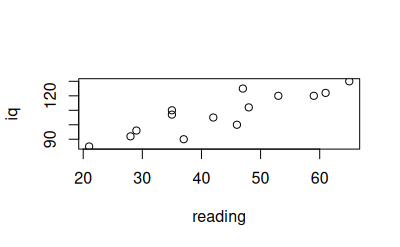

```r
#a
#View(Readiq)
# Merkmale sind reading und iq

#b
# scatter.smooth liefert graph mit kurven
#scatter.smooth(x = Readiq$iq, y = Readiq$reading)
# plot liefert nur punkte, ist so gefordert
plot(Readiq)
```

```r
#c
# Koorelation von 0,87, sehr hoch positiv, bedeutet hohe Korrelation
cor(Readiq$reading, Readiq$iq)
```

```
[1] 0.8730177
```

```r
#d
r <- cor(Readiq$reading, Readiq$iq)
varianz_reading <- sd(Readiq$reading)
varianz_iq <- sd(Readiq$iq)

a <- r * (varianz_reading / varianz_iq)
a
```

```
[1] 0.8174586
```

```r
b <- mean(Readiq$reading) - a * mean(Readiq$iq)
b
```

```
[1] -45.11659
```

```r
model <- lm(reading ~ iq, data = Readiq)

scatter.smooth(x = Readiq$iq, y = Readiq$reading)
abline(model, col = "red", lwd = 2)
```

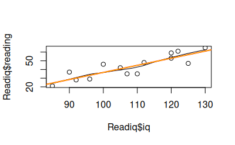

```r
abline(c(b,a), col = "yellow")
```

## Aufgabe 9.2 (Regressionsrechnung)

Über die Einführung des Mindestlohns wurde lange diskutiert. Ende 2007 veröffentlichte die *Wirtschaftswoche* folgende Daten zu Mindestlohn (in Euro) und Arbeitslosenquote (in Prozent):

```r
library(knitr)
mindestlohn_tabelle <- data.frame(row.names = c("Irland", "Frankreich", "Großbritannien",
                                            "Belgien", "Niederlande", "USA", "Spanien"),
                          Mindestlohn = c(8.65, 4.44, 8.2, 8.08, 8.08, 4.3, 3.42),
                          Arbeitslosenquote = c(4.4, 9.0, 5.5, 8.2, 5.5, 4.6, 8.5))

kable(mindestlohn_tabelle)
```

|  | Mindestlohn | Arbeitslosenquote |
| --- | --- | --- |
| Irland | 8.65 | 4.4 |
| Frankreich | 4.44 | 9.0 |
| Großbritannien | 8.20 | 5.5 |
| Belgien | 8.08 | 8.2 |
| Niederlande | 8.08 | 5.5 |
| USA | 4.30 | 4.6 |
| Spanien | 3.42 | 8.5 |

Gibt es einen linearen Zusammenhang zwischen *Mindestlohn* (unabhängige Variable) und *Arbeitslosenquote*? Stellen Sie die Daten in einem Streudiagramm dar, berechnen Sie die Regressionsgerade und fügen Sie sie dem Streudiagramm zu. Ist die Regressionsgerade eine sinnvolle Beschreibung der Daten?

Hinweis: Benutzen Sie diesmal die Funktion `lm()` in R zur Berechnung der Regressionsgeraden. Weisen Sie das Ergebnis des Aufrufs einer Variablen zu: `regression <- lm(...)`. Untersuchen Sie die Ausgabe von `regression` und `summary(regression)` und vergleichen Sie zur Interpretation auch die Folien der Vorlesung.

```r
round(cor(mindestlohn_tabelle$Mindestlohn, mindestlohn_tabelle$Arbeitslosenquote),2)
```

```
[1] -0.46
```